# Comparison of Web-CDI Data Collected from Amazon Mechanical Turk against Data from Aggregated CDI studies

2017-01-13

Load up necessary packages and scripts for accessing both the Wordbank MySQL database and the Web-CDI database.

```r
library(tidyverse)
library(quantregGrowth)
library(wordbankr)
library(langcog)
library(stringr)
library(RPostgreSQL)
library(lubridate)
library(robustbase)
library(forcats)
theme_set(theme_mikabr(base_size = 14) + theme(panel.border = element_rect(fill = NA) ))

source("access-webcdi.R")
source("predictQR_fixed.R")
mode <- "remote"
compare_newest_studies <- F
newest_studies <- "MTurk-5"
# taus <- seq(0.01,0.99, 0.01)
taus <-  c(0.1, 0.25, 0.5, 0.75, 0.9)
```

Word categories classified into nouns and verbs

```r
nouns <- c("animals", "vehicles","toys","food_drink","clothing","body_parts","furniture_rooms","household","outside","people")
verbs <- c("action_words","helping_verbs")
```

Collect data from wordbank.

```r
num_words <- get_item_data() %>%
  filter(type == "word") %>%
  group_by(language, form) %>%
  summarise(n = n())

vocab_data <- get_administration_data() %>%
  select(data_id, language, form, age, sex,
         mom_ed, birth_order, production, comprehension, source_name) %>%
  left_join(num_words) %>%
  mutate(no_production = n - production)

min_age <- min(vocab_data$age)
max_age <- max(vocab_data$age)
```

Functions for modelling quantiles for Wordbank data.

```r
fit_gcrq <- function(x) {
  mod <- try(gcrq(formula = mean ~ ps(age, monotone = 1,
                                      lambda = 1000),
                  tau = taus, data = x))

  if(inherits(mod, "try-error"))
  {
    return(NA)
  }

  return(mod)
}

pred_gcrq <- function(x, mods) {
  mod <- mods[[x$language[1]]]

  if (is.na(mod[1])) {
    return(expand.grid(age = x$age,
                       language = x$language[1],
                       percentile = as.character(taus*100),
                       pred = NA))
  } else {
    preds <- predictQR_fixed(mod,
                             newdata = x) %>%
      data.frame %>%
      mutate(age = x$age,
             language = x$language) %>%
      gather(percentile, pred, starts_with("X")) %>%
      mutate(percentile = as.character(as.numeric(str_replace(percentile,
                                                              "X", ""))
                                       * 100))
    return(preds)
  }
}

fit_sex <- function(x) {
  robustbase::glmrob(cbind(production, no_production) ~ age * sex - sex,
                     family = "binomial",
                     data = x)
}

pred_sex_language <- function(x, model) {
  x$pred <- predict(model[[x$language[1]]],
                    newdata = x, type = "response")
  return(x)
}

pred_sex_source <- function(x, model) {
  x$pred <- predict(model[[x$source[1]]],
                    newdata = x, type = "response")
  return(x)
}

fit_ses <- function(x) {
  robustbase::glmrob(cbind(production, no_production) ~
                       age * mom_ed  - mom_ed,
                     family = "binomial",
                     data = x)
}

pred_ses_language <- function(x, model) {
  x$pred <- predict(model[[x$language[1]]],
                    newdata = x, type = "response")
  return(x)
}

pred_ses_source <- function(x, model) {
  x$pred <- predict(model[[x$source[1]]],
                    newdata = x, type = "response")
  return(x)
}
```

Grab English WG comprehension data from Wordbank and plot alone with model

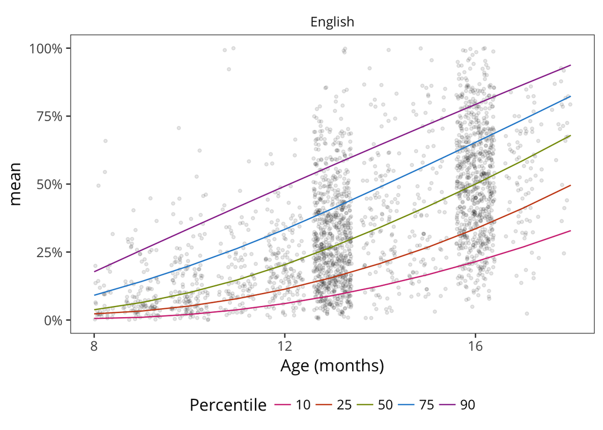

```r
comp_data <- vocab_data %>%
  filter(form == "WG" &  language == "English") %>%
  mutate(mean = comprehension / n)

comp_models <- comp_data %>%
  split(.$language) %>%
  map(fit_gcrq)

comp_preds <- comp_data %>%
  group_by(language, age) %>%
  summarise(n = n()) %>%
  data.frame() %>%
  split(.$language) %>%
  map_df(function(x) pred_gcrq(x, comp_models))

wordbank_comprehension_plot <- ggplot(comp_data,
       aes(x = age, y = mean)) +
  facet_wrap(~language) +
  geom_jitter(width = .4, size = 1, alpha = .1) +
  geom_line(data = comp_preds,
            aes(y = pred, col = percentile, group = percentile)) +
  scale_colour_solarized(name="Percentile") +
  scale_x_continuous(breaks = seq(8, 18, 4),
                     limits = c(8, 18),
                     name = "Age (months)") +
  scale_y_continuous(limits = c(0,1), labels = scales::percent) +
  theme(legend.position = "bottom")

print(wordbank_comprehension_plot)
```

Grab production data from English WG and WS for Wordbank and plot data alone with model

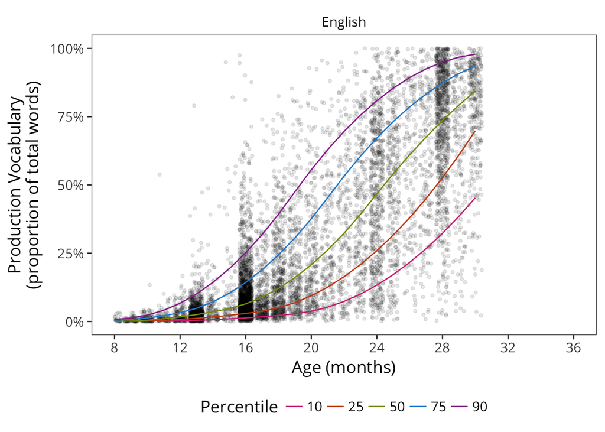

```r
prod_data <- vocab_data %>%
  filter(language == "English") %>%
  mutate(mean = production / n)

prod_models <- prod_data %>%
  split(.$language) %>%
  map(fit_gcrq)

prod_preds <- prod_data %>%
  group_by(language, age) %>%
  summarise(n = n()) %>%
  data.frame() %>%
  split(.$language) %>%
  map_df(function(x) pred_gcrq(x, prod_models))

wordbank_production_plot <- ggplot(prod_data,
       aes(x = age, y = mean)) +
  facet_wrap(~language) +
  geom_jitter(width = .4, size = 1, alpha = .1) +
  geom_line(data = prod_preds,
            aes(y = pred, col = percentile, group = percentile)) +
  scale_colour_solarized(name="Percentile") +
  scale_x_continuous(breaks = seq(8, 36, 4),
                     limits = c(8, 36),
                     name = "Age (months)") +
  ylab("Production Vocabulary\n(proportion of total words)") +
  scale_y_continuous(limits = c(0,1), labels = scales::percent) +
  theme(legend.position = "bottom")

print(wordbank_production_plot)
```

Access Web-CDI database and find data from the studies of interest (labeled ‘MTurk’). Grab the related CDI items. There are one set each for the two instruments.

```r
webcdi <- connect_to_webcdi(mode=mode)
study_info <- get_common_table(webcdi, "researcher_UI_study") %>% as.data.frame() %>% filter(grepl('MTurk', name)) %>% rename(study_id = id, instrument = instrument_id)
instruments <- unique(study_info$instrument)
study_items <- list()

for (i in 1:length(instruments)){
  temp <- get_common_table(webcdi, paste("cdi_forms", tolower(instruments[i]), sep="_")) %>% as.data.frame() %>% rename(item_ID = itemID)
  study_items[[i]] <- temp
  study_items[[i]]$instrument <- instruments[i]
}

cdi_items <- bind_rows(study_items) %>% filter(!grepl('example', item_ID))
```

Grab Web-CDI by-child data (administration details, demographic information, and given answers)

```r
admin_info <- get_common_table(webcdi, "researcher_UI_administration") %>% as.data.frame() %>% filter(study_id %in% study_info$study_id & completed) %>% rename(administration_id = id)

background_info <- get_common_table(webcdi, "cdi_forms_backgroundinfo") %>% as.data.frame() %>% filter(administration_id %in% admin_info$administration_id) %>% filter(birth_weight >= 5.5)

cdi_answers <- get_common_table(webcdi, "researcher_UI_administration_data") %>% as.data.frame() %>% filter(administration_id %in% admin_info$administration_id) %>% select(-id)
```

Merge Web-CDI tables. Calculate proportions of words understood and words produced.

```r
combined_data <- left_join(background_info, admin_info, by = "administration_id") %>% left_join(., study_info, by = "study_id") %>% left_join(., cdi_items, by = c("instrument")) %>% left_join(., cdi_answers, by = c("administration_id", "item_ID")) %>% filter( grepl('WG', instrument) & (age >= 8 & age <= 18) | grepl('WS', instrument) & (age >= 16 & age <= 30))

combined_words <- combined_data %>% filter(item_type == "word")
combined_words$value[is.na(combined_words$value)] <- "neither"

combined_words$word_type[combined_words$category %in% nouns] <- "nouns"
combined_words$word_type[combined_words$category %in% verbs] <- "verbs"
```

Combine wordbank and Web-CDI data into a single dataframe for later facet graphs

```r
slim_wordbank_data <- vocab_data %>% filter(language == "English") %>% rename(id = data_id, study_group = source_name) %>% select(id, form, age, sex, study_group, mom_ed, production, comprehension, n) %>% mutate(source = "wordbank", mom_ed = fct_collapse(mom_ed,
                               `Below Secondary` = c("None","Primary",
                                                     "Some Secondary"),
                               `Secondary` = c("Secondary", "Some College"),
                               `College and Above` = c("College",
                                                       "Some Graduate",
                                                       "Graduate")))

slim_webcdi_data <- combined_words %>% group_by(id, instrument, age, sex, study_group, mother_education) %>% summarise(comprehension = sum(value == "understands" | value == "produces"), production = sum(value == "produces"), n = n(), source = "webcdi", form = NA, mom_ed = NA) %>% rename(sex_old = sex) %>% mutate(sex = ifelse(sex_old == "F", "Female", ifelse(sex_old == "M", "Male", NA))) %>% select (-sex_old)

slim_webcdi_data$form[grepl('WG', slim_webcdi_data$instrument)] <- "WG"
slim_webcdi_data$form[grepl('WS', slim_webcdi_data$instrument)] <- "WS"

slim_webcdi_data$mom_ed[slim_webcdi_data$mother_education %in% 0:9] <- "Below Secondary"
slim_webcdi_data$mom_ed[slim_webcdi_data$mother_education %in% 10:15] <- "Secondary"
slim_webcdi_data$mom_ed[slim_webcdi_data$mother_education %in% 16:25] <- "College and Above"

slim_webcdi_data$instrument <- slim_webcdi_data$mother_education <- NULL

a <- list(slim_webcdi_data, slim_wordbank_data)

for (i in 1:length((a))) {
  temp <- a[[i]]
  temp <- temp[,c("source","id","form","study_group","age","sex","mom_ed","production","comprehension","n")]
  a[[i]] <- temp

}

both_data <- bind_rows(a) %>% mutate(no_production = (n-production))
```

Plot Wordbank data with Web-CDI data (in red) along with the original model lines.

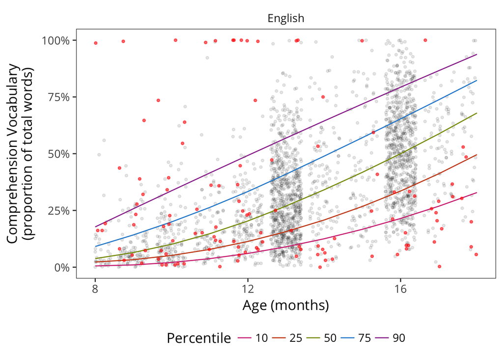

```r
if (compare_newest_studies) {
  combined_words$newest <- FALSE
  combined_words$newest[combined_words$study_group == newest_studies] <- TRUE

  prop_measures <- combined_words %>% group_by(id, age, newest) %>% summarise(comprehension = sum(value == "understands" | value == "produces")/n(), production = sum(value == "produces")/n())

  prop_measures_old <- prop_measures %>% filter(!newest)
  prop_measures_new <- prop_measures %>% filter(newest)
} else {
    prop_measures <- combined_words %>% group_by(id, age) %>% summarise(comprehension = sum(value == "understands" | value == "produces")/n(), production = sum(value == "produces")/n())
}


combined_comprehension_plot <- ggplot(comp_data,
       aes(x = age, y = mean)) +
  facet_wrap(~language) +
  geom_jitter(width = .4, size = 1, alpha = .1) +
  geom_line(data = comp_preds,
            aes(y = pred, col = percentile, group = percentile))

  if (compare_newest_studies) {
    combined_comprehension_plot <- combined_comprehension_plot + geom_jitter(width = .4, size = 1, alpha = .6, colour = "#249D00", data=prop_measures_old, aes(x = age, y = comprehension)) +
    geom_jitter(width = .6, size = 1, alpha = .6, colour = "red", data=prop_measures_new, aes(x = age, y = comprehension))
  } else{
    combined_comprehension_plot <- combined_comprehension_plot + geom_jitter(width = .4, size = 1, alpha = .6, colour = "red", data=prop_measures, aes(x = age, y = comprehension))
  }

  combined_comprehension_plot <- combined_comprehension_plot + scale_colour_solarized(name="Percentile") +
  scale_x_continuous(breaks = seq(8, 18, 4),
                     limits = c(8, 18),
                     name = "Age (months)") +
  ylab("Comprehension Vocabulary\n(proportion of total words)") +
  scale_y_continuous(limits = c(0,1), labels = scales::percent) +
  theme(legend.position = "bottom")

  print(combined_comprehension_plot)
```

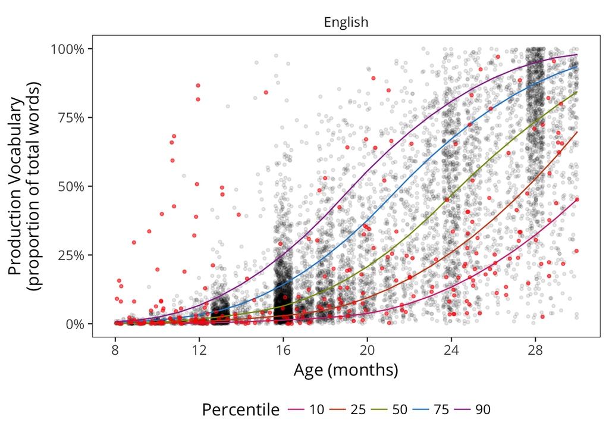

```r
combined_production_plot <- ggplot(prod_data,
       aes(x = age, y = mean)) +
  facet_wrap(~language) +
  geom_jitter(width = .4, size = 1, alpha = .1) +
  geom_line(data = prod_preds,
            aes(y = pred, col = percentile, group = percentile))

  if (compare_newest_studies) {
    combined_production_plot <- combined_production_plot + geom_jitter(width = .4, size = 1, alpha = .6, colour = "#249D00", data=prop_measures_old, aes(x = age, y = production)) +
  geom_jitter(width = .4, size = 1, alpha = .6, colour = "red", data=prop_measures_new, aes(x = age, y = production))

  } else {
    combined_production_plot <- combined_production_plot + geom_jitter(width = .4, size = 1, alpha = .6, colour = "red", data=prop_measures, aes(x = age, y = production))
  }

  combined_production_plot <- combined_production_plot + scale_colour_solarized(name="Percentile") +
  scale_x_continuous(breaks = seq(8, 30, 4),
                     limits = c(8, 30),
                     name = "Age (months)") +
  ylab("Production Vocabulary\n(proportion of total words)") +
  scale_y_continuous(limits = c(0,1), labels = scales::percent) +
  theme(legend.position = "bottom")

  print(combined_production_plot)
```

Binned report of the % of words on the test reported as produced. Not a ranking.

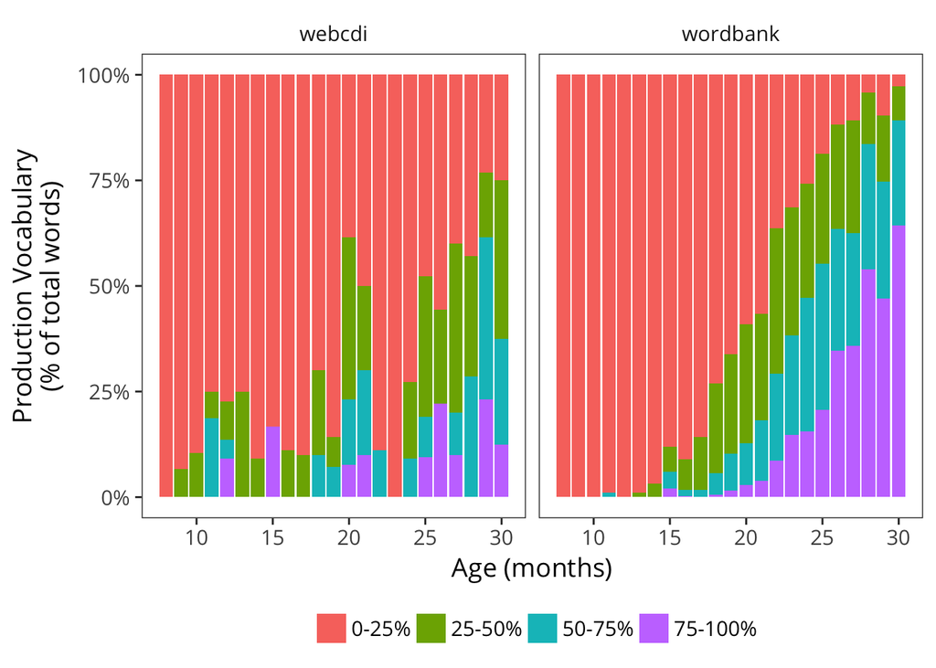

```r
binned_data <- both_data %>% group_by(id, age, form, source) %>% summarise(prop_prod = mean(production/n))

binned_data$`% of Words Produced`[binned_data$prop_prod < 0.25] <- "0-25%"
binned_data$`% of Words Produced`[binned_data$prop_prod >= 0.25 & binned_data$prop_prod < 0.50] <- "25-50%"
binned_data$`% of Words Produced`[binned_data$prop_prod >= 0.50 & binned_data$prop_prod < 0.75] <- "50-75%"
binned_data$`% of Words Produced`[binned_data$prop_prod >= 0.75] <- "75-100%"

binned_production_comparison_plot <- ggplot(binned_data, aes(age, fill=`% of Words Produced`)) + geom_bar(position = "fill", width=0.9) + scale_y_continuous(labels = scales::percent) + facet_wrap(~source) + labs(y = "Production Vocabulary\n(% of total words)", x="Age (months)", fill = "") + theme(legend.position = "bottom")

print(binned_production_comparison_plot)
```

Percentile ranking based on original Wordbank production data. Wordbank graph included as a sanity check (each group should be around 25% for Wordbank data)

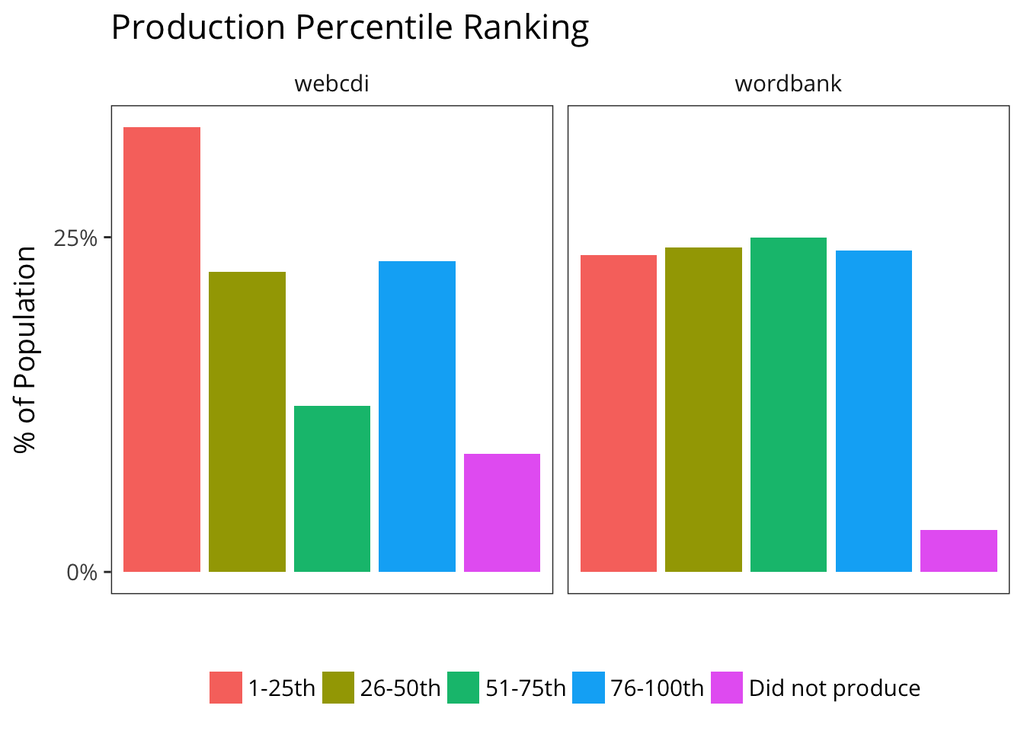

```r
taus <- seq(0.01,0.99, 0.01)

prod_models_perc <- prod_data %>%
  split(.$language) %>%
  map(fit_gcrq)

prod_preds_perc <- prod_data %>%
  group_by(language, age) %>%
  summarise(n = n()) %>%
  data.frame() %>%
  split(.$language) %>%
  map_df(function(x) pred_gcrq(x, prod_models_perc))

prop_prod <- both_data  %>% group_by(age) %>% filter(study_group %in% c("MTurk-3","MTurk-4","MTurk-5") | source == "wordbank") %>% mutate(prop_production = production/n, quantile = NA)


for (i in 1:nrow(prop_prod)) {
  current_age <- prop_prod$age[i]
  current_prod <- prop_prod$prop_production[i]

  ranges_at_age <- prod_preds_perc %>% filter(age == current_age, pred < current_prod)

  prop_prod$quantile[i] <- max(max(as.numeric(as.character(ranges_at_age$percentile))),1)


}

prop_prod$quantile[prop_prod$production == 0] <- 0
prop_prod$bin_quantile <- as.character(cut(prop_prod$quantile, seq(0,100, 25), labels = c("1-25th","26-50th","51-75th","76-100th")))
prop_prod$bin_quantile[prop_prod$production == 0] <- "Did not produce"

webcdi_prop_prod <- prop_prod %>% filter(source == "webcdi")
wordbank_prop_prod <- prop_prod %>% filter(source == "wordbank")

prop_prod_perc <- prop_prod %>%
  group_by(source,bin_quantile) %>%
  summarise(n=n()) %>%
  group_by(source) %>%
  mutate(perc=n/sum(n))

combined_ranking_overall <- ggplot(prop_prod_perc, aes(x = factor(bin_quantile), y= perc, fill=factor(bin_quantile))) + facet_wrap(~source) + geom_bar(stat="identity")+ scale_y_continuous(breaks = seq(0,1,0.25), labels = scales::percent) + labs(x = "", fill="", y="% of Population", title = "Production Percentile Ranking") + theme(legend.position = "bottom", axis.text.x = element_blank(), axis.ticks.x = element_blank())

print(combined_ranking_overall)
```

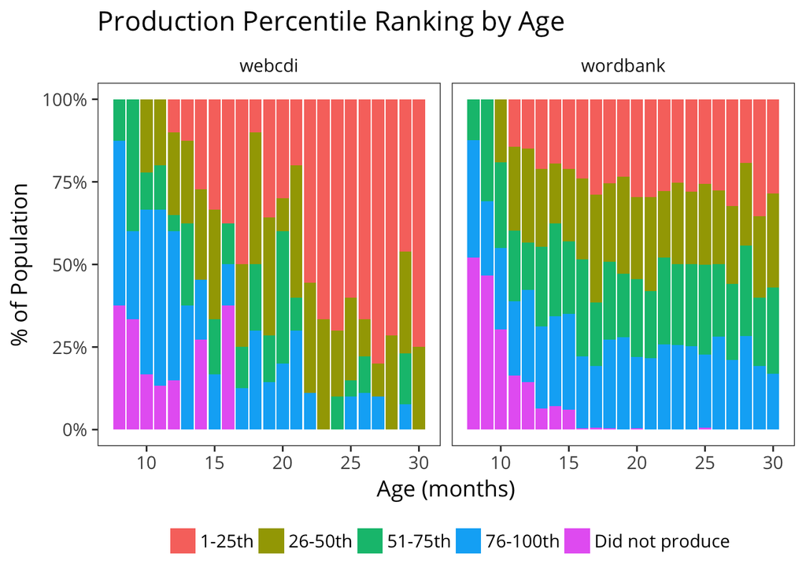

```r
combined_ranking_data_age <- ggplot(prop_prod, aes(age, fill=factor(bin_quantile))) + geom_bar(position = "fill", width=0.9) + facet_wrap(~source) + scale_y_continuous(breaks = seq(0,1,0.25), labels = scales::percent) + labs(fill = "", y = "% of Population", x = "Age (months)", title = "Production Percentile Ranking by Age") + theme(legend.position = "bottom")

print(combined_ranking_data_age)
```

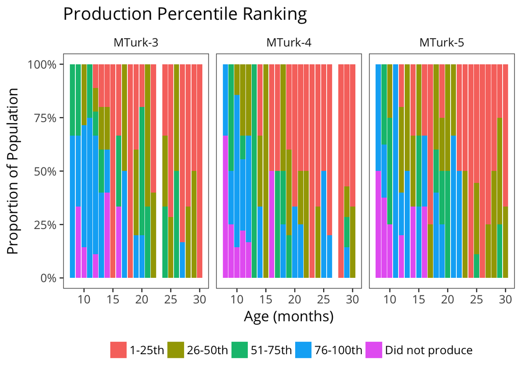

```r
webcdi_ranking_study_age <- ggplot(webcdi_prop_prod, aes(age, fill=factor(bin_quantile))) + geom_bar(position = "fill", width=0.9) + facet_wrap(~study_group) + scale_y_continuous(breaks = seq(0,1,0.25), labels = scales::percent) + labs(title = "Production Percentile Ranking", y = "Proportion of Population", x = "Age (months)", fill="") + theme(legend.position = "bottom")

print(webcdi_ranking_study_age)
```

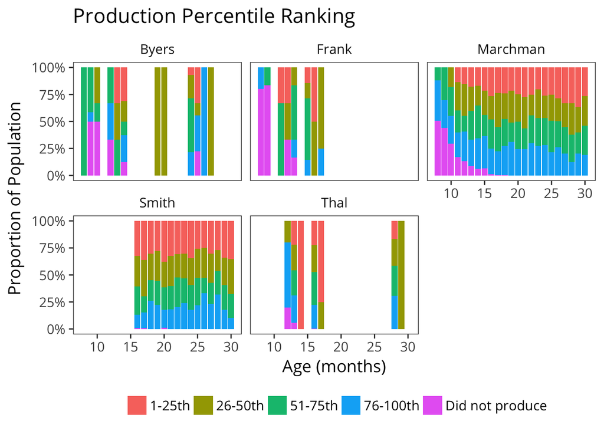

```r
wordbank_ranking_study_age <- ggplot(wordbank_prop_prod, aes(age, fill=factor(bin_quantile))) + geom_bar(position = "fill", width=0.9) + facet_wrap(~study_group) + scale_y_continuous(breaks = seq(0,1,0.25), labels = scales::percent) + labs(title = "Production Percentile Ranking", x="Age (months)", y="Proportion of Population", fill = "") + theme(legend.position = "bottom")

print(wordbank_ranking_study_age)
```

```r
taus <-  c(0.1, 0.25, 0.5, 0.75, 0.9)
```

Maternal education differenes in vocab norms

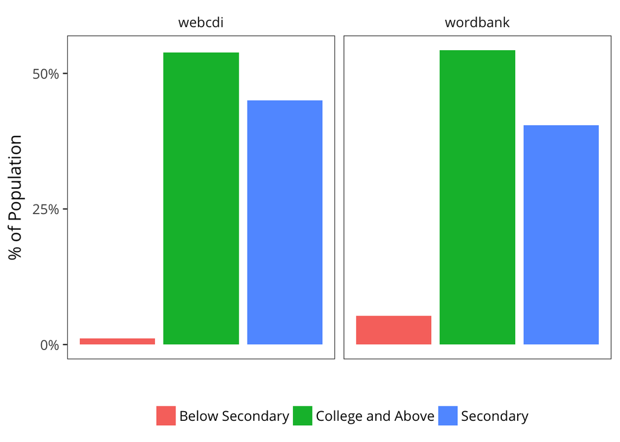

```r
ses_data <- both_data %>% filter(!is.na(mom_ed))

ses_means <- ses_data %>%
  group_by(mom_ed, age, source) %>%
  mutate(mean_production = production/n) %>%
  summarise(median = median(mean_production), n = n())

prop_ses_perc <- ses_data %>%
  group_by(source,mom_ed) %>%
  summarise(n=n()) %>%
  group_by(source) %>%
  mutate(perc=n/sum(n))

ses_composition <- ggplot(prop_ses_perc, aes(x = factor(mom_ed), y= perc, fill=factor(mom_ed))) + facet_wrap(~source) + geom_bar(stat="identity")+ scale_y_continuous(breaks = seq(0,1,0.25), labels = scales::percent) + labs(x = "", fill="", y="% of Population") + theme(legend.position = "bottom", axis.text.x = element_blank(), axis.ticks.x = element_blank())

print(ses_composition)
```

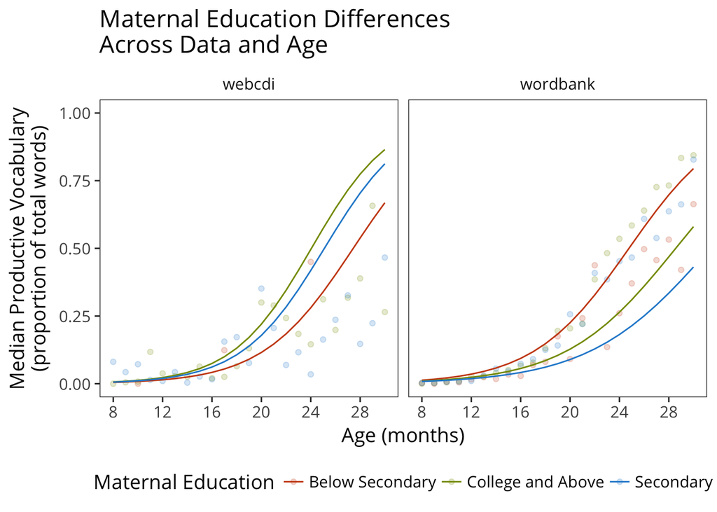

```r
ses_models <- ses_data %>%
  split(.$source) %>%
  map(fit_ses)

ses_preds <- expand.grid(source = unique(ses_means$source),
                         age = min(ses_means$age):max(ses_means$age),
                         mom_ed = unique(ses_means$mom_ed)) %>%
  split(.$source) %>%
  map_df(pred_ses_source, model = ses_models)

ses_plot <- ggplot(ses_means,
       aes(x = age, y = median, colour = mom_ed, label = mom_ed)) +
  facet_wrap(~source) +
  geom_point(alpha=.2) +
  geom_line(data = ses_preds, aes(y = pred)) +
  scale_colour_solarized(name="Maternal Education") +
  scale_x_continuous(breaks = seq(min(ses_means$age),
                                  max(ses_means$age), 4),
                     limits = c(min(ses_means$age), max(ses_means$age)),
                     name = "Age (months)") +
  labs(title = "Maternal Education Differences\nAcross Data and Age", y = "Median Productive Vocabulary\n(proportion of total words)", colour = "") +
  ylim(c(0, 1)) +
  theme(legend.position = "bottom")
print(ses_plot)
```

Sex differences in vocab norms

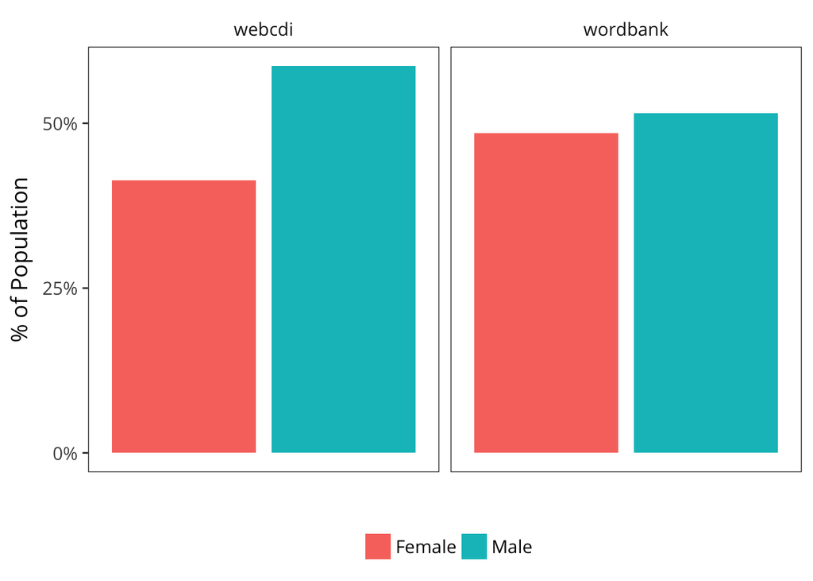

```r
sex_data <- both_data %>% filter(sex %in% c("Male","Female")) %>% mutate(mean_production = production/n)

prop_sex_perc <- sex_data %>%
  group_by(source,sex) %>%
  summarise(n=n()) %>%
  group_by(source) %>%
  mutate(perc=n/sum(n))

sex_composition <- ggplot(prop_sex_perc, aes(x = factor(sex), y= perc, fill=factor(sex))) + facet_wrap(~source) + geom_bar(stat="identity")+ scale_y_continuous(breaks = seq(0,1,0.25), labels = scales::percent) + labs(x = "", fill="", y="% of Population") + theme(legend.position = "bottom", axis.text.x = element_blank(), axis.ticks.x = element_blank())

print(sex_composition)
```

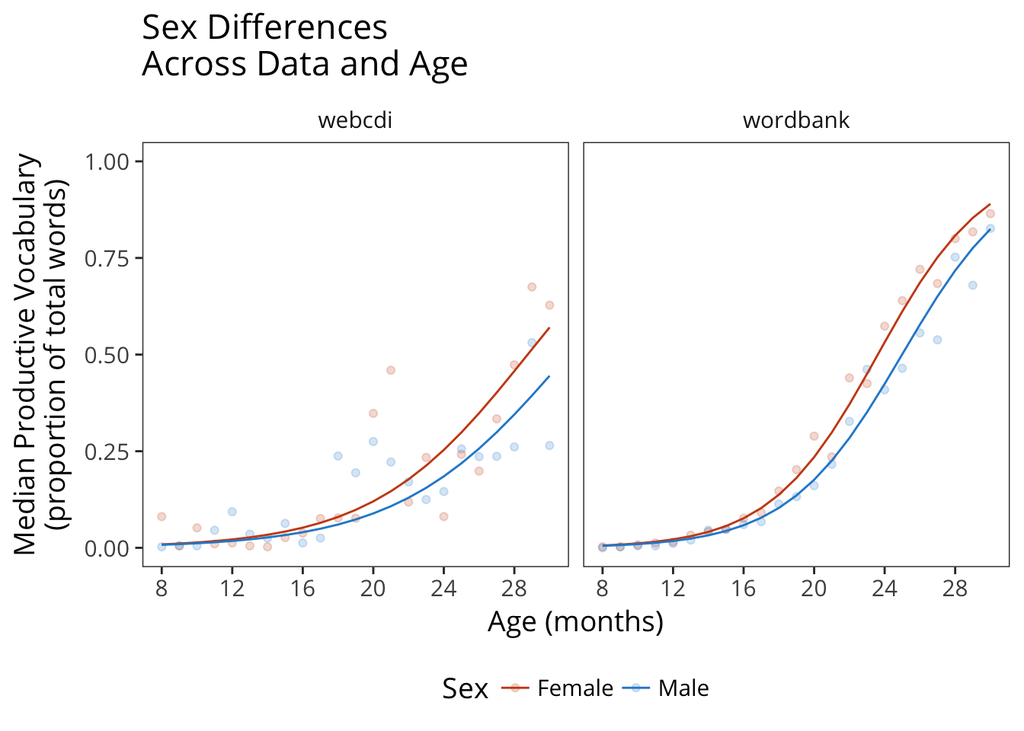

```r
sex_means <- sex_data %>% group_by(sex, age, source) %>% summarise(production = median(mean_production))

sex_models <- sex_data %>%
  split(.$source) %>%
  map(fit_sex)

sex_preds <- expand.grid(source = unique(sex_means$source),
                         age = min(sex_means$age):max(sex_means$age),
                         sex = unique(sex_means$sex)) %>%
  split(.$source) %>%
  map_df(pred_sex_source, model = sex_models)

sex_plot <- ggplot(sex_means,
       aes(x = age, y = production, colour = sex, label = sex)) +
  facet_wrap(~source) +
  geom_point(alpha=.2) +
  geom_line(data = sex_preds, aes(y = pred)) +
  scale_colour_solarized(name="Sex") +
  scale_x_continuous(breaks = seq(min(sex_means$age),
                                  max(sex_means$age), 4),
                     limits = c(min(sex_means$age), max(sex_means$age)),
                     name = "Age (months)") +
  labs(title = "Sex Differences\nAcross Data and Age", y = "Median Productive Vocabulary\n(proportion of total words)", colour = "") +
  ylim(c(0, 1)) +
  theme(legend.position = "bottom")

print(sex_plot)
```